# TT Overall Overview

```
## [1] "QC filter? TRUE"
```

```
## [1] "Which pilot paradigm? 2"
```

Participants and counterbalancing

| counterbalancing | prolific_id | n |
| --- | --- | --- |
| dense_left | sub_18 | 1 |
| dense_left | sub_20 | 1 |
| dense_left | sub_24 | 1 |
| dense_left | sub_28 | 1 |
| dense_left | sub_29 | 1 |
| dense_left | sub_30 | 1 |
| dense_right | sub_17 | 1 |
| dense_right | sub_19 | 1 |
| dense_right | sub_21 | 1 |
| dense_right | sub_22 | 1 |
| dense_right | sub_25 | 1 |
| dense_right | sub_26 | 1 |

# Summary stats for various combinations of factors.

(Code hidden) Calculates some tables for plotting them below.

# Plots over all trials

Show data for Pre, post, and post-minus-pre difference. Also, show combined data and broken down by the two counterbalancing conditions (dense_left and dense_right).

These plots do not address the questions we’re interested in, because they average over all types of triplets from all templates located anywhere along the dimension.

But its good to see that accuracy is alright: around 75% pre and post.

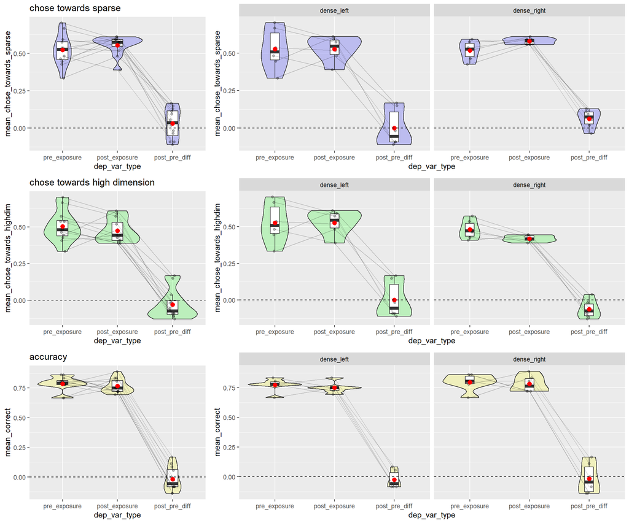

# Plots over triplet location

Below, we are already examining our crucial contrast: did the “behavior change post vs pre” differ for triplets in the sparse/dense/middle areas?

If we look at the left column of plots, averaging over the 2 counterbalancing conditions, we see that in the middle regions, the probability to “choose towards sparse” increases post vs pre-exposure. This increase is larger for the middle regions than the outer ones. But looking at the counterbalancing groups, this effect might be driven by the dense_right subgroup.

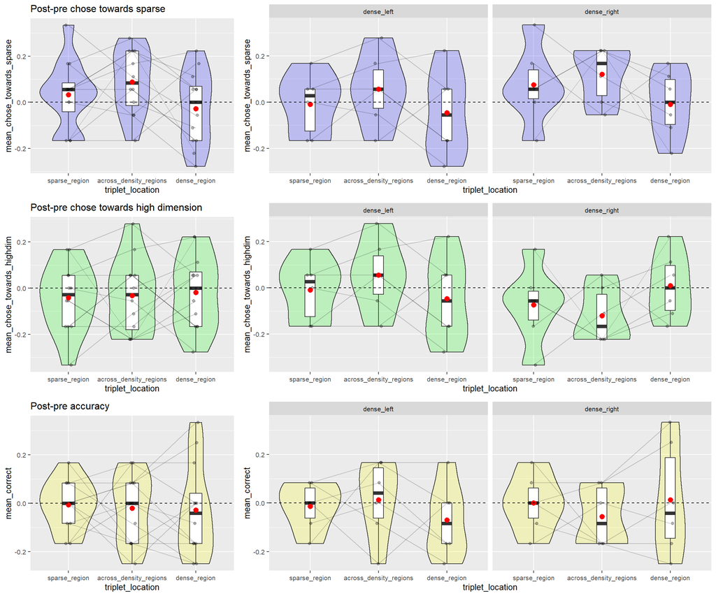

# Plots over curve type

I categorize triplets as being either in the concave region, convex region, or in the middle.

The plots below show data largely similar to the above panel. But its more intuitive that for both counterbalancing groups, on the x axis going from left-to-right corresponds to going from left-to-right on the actual dimension axis of the stimuli.

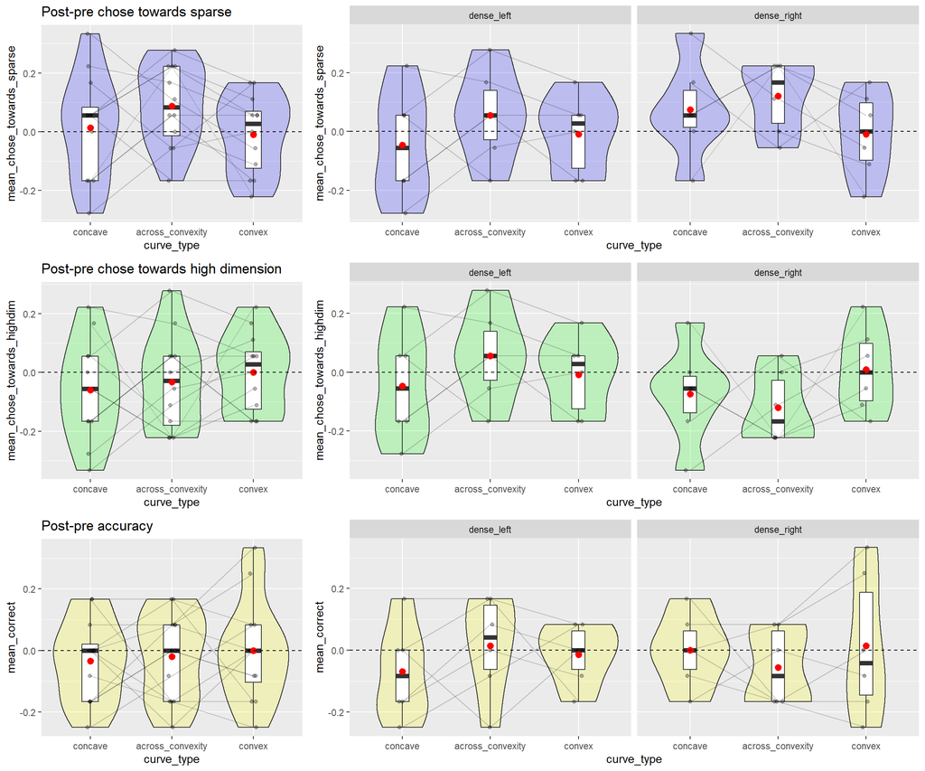

# Plots over curve type and easiness

We have 3 levels of “easiness” in our TEMPlates.

- Easiness = 0: these are symmetric templates, where both referents are equally distant from the query.
- Easiness = 8: here, the distance(query,ref1) is 8 units larger than distance(query,ref2). So its easier to see which refs is closer
- Easiness = 16: here, its even more easy to see which ref is closer to query.

So, its useful to check which of these templates are driving the overall effects we see above.

It seems like its the templates wiht easiness=0 and easiness=8. For easiness=16, the post-pre difference is essentially 0.

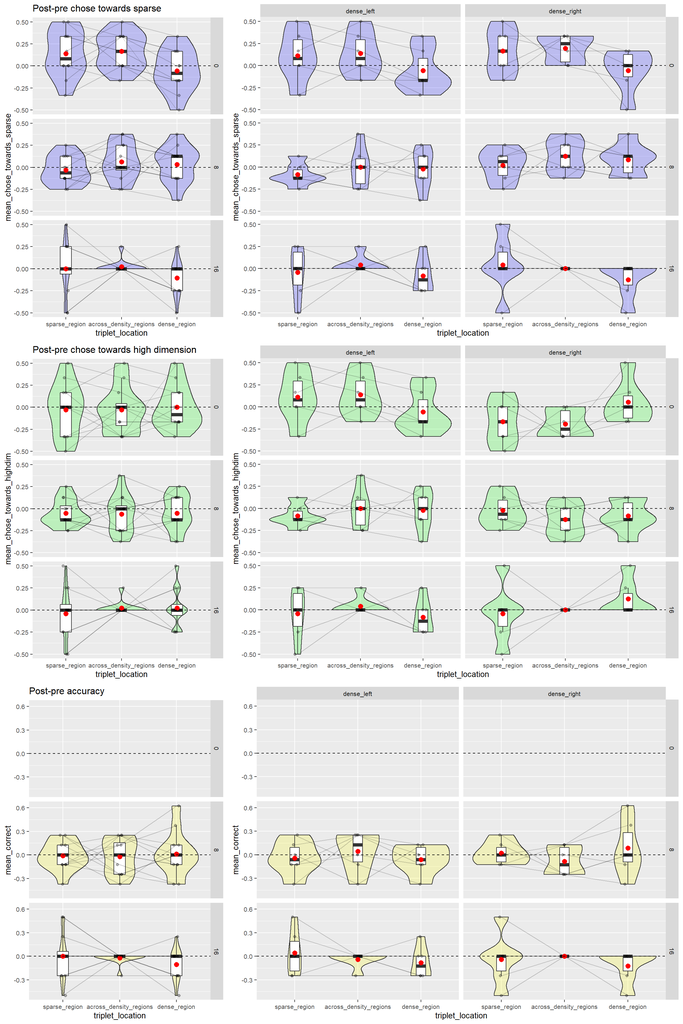

# Plots for each easiness level: triplet location by template

For each easiness level, we have several types of templates. So the plots below simply further break down the plots from the previous panel, plotting data for each template separately.

This is just in case there is a really strong signal showing us that one of the templates is really great while others not.

I think the data is too noisy here.

```
## [1] "0"
```

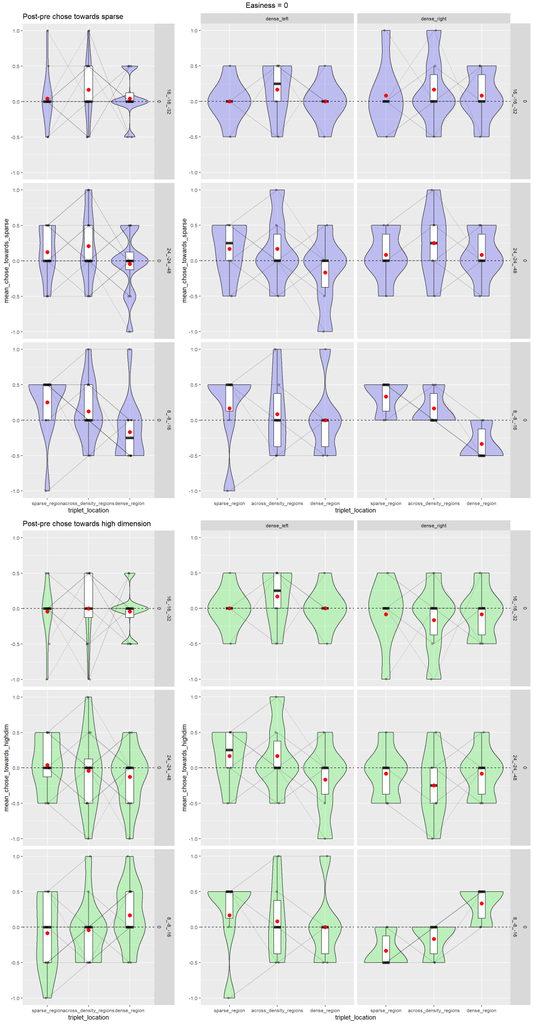

```
## [1] "8"
```

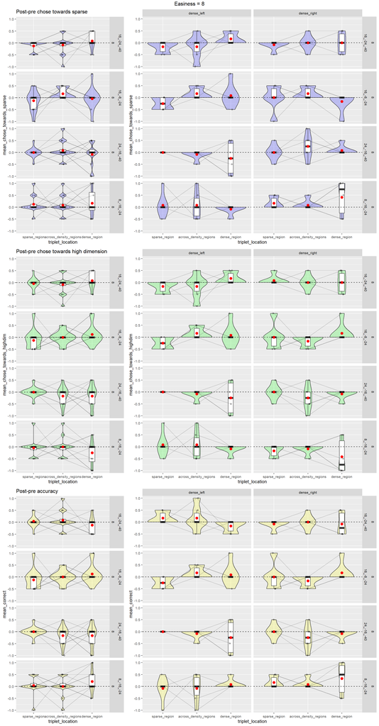

```
## [1] "16"
```

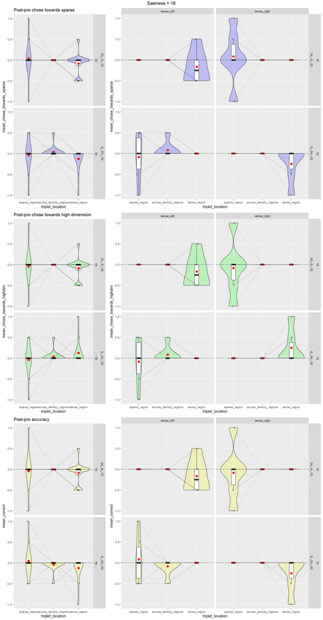

# Between participant comparisons:

We’ve already seen these in sections above, where I break it down by dense_left vs dense_right.

But its useful to plot the data from the two counterbalancing groups next to each other, along with 95% confidence intervals for a quick eye-balling of stats.

## Averaging over all triplets:

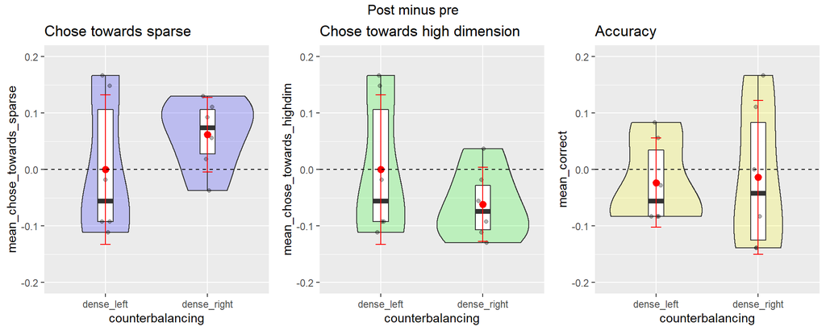

## Curve type breakdown:

If density stretches the psychological space then what we want to see below is the following:

- The probability of choosing towards sparse should increase for both counterbalancing groups.
- The prob of choosing highdimensional referent should increase for dense_left and decrease for dense_right.

We see the above pattern but only for the triplets located across the density boundary!

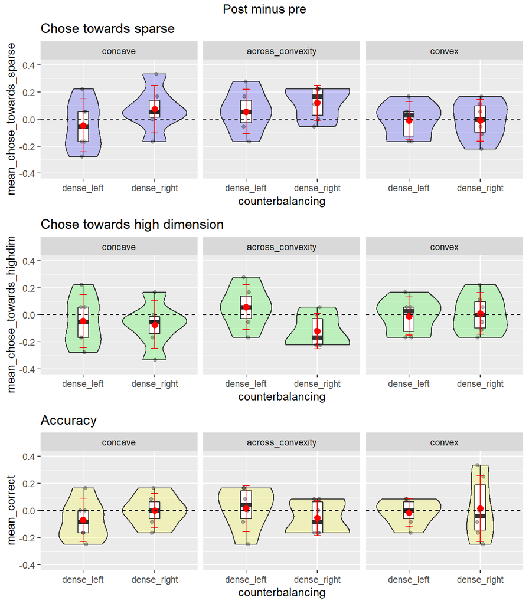

## Triplet location

Similar to the breakdown by curve type in the previous panel.

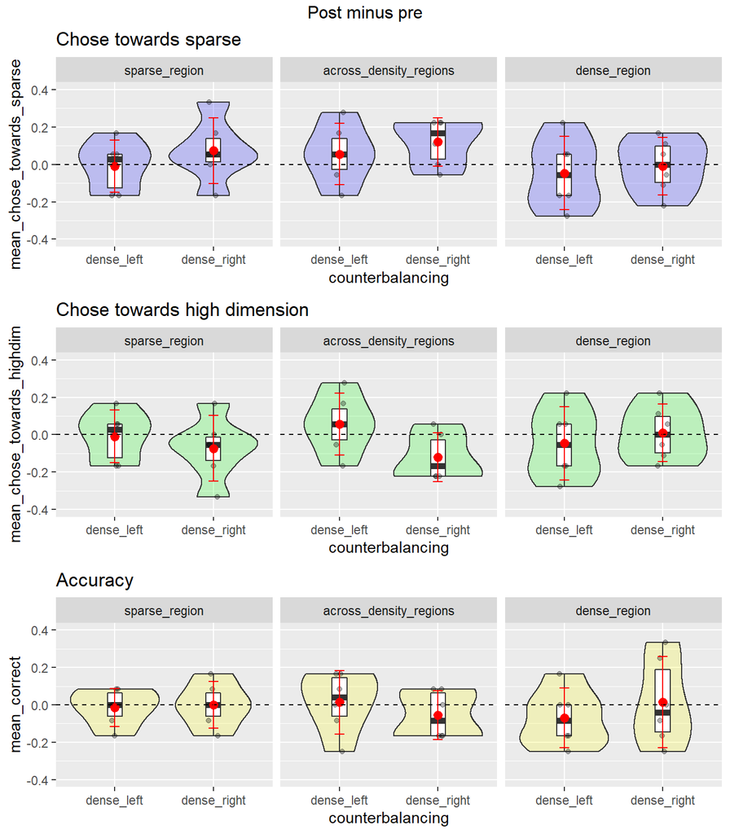

## Triplet location by template breakdown:

Now here, its interesting to see which of the templates are driving the effect in the “across_density_regions” plots.

It seems to be again the ones that are either symmetric, or easiness=8

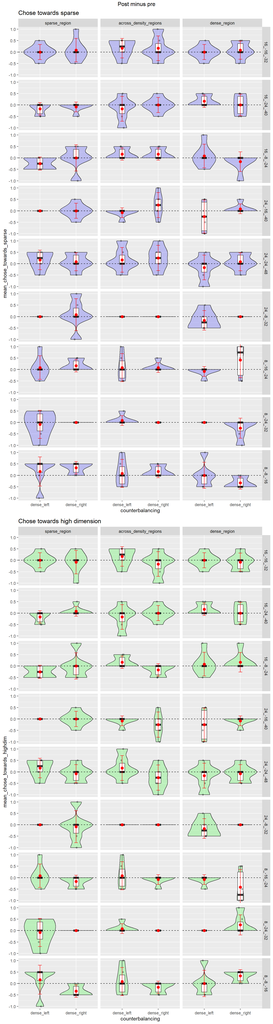